# A/Bテストの分析

Author

Seiro Ito

# 1 What’s new 2024-10-10

- A/B: いずれの結果指標においても、どちらが優れているとは言えない

# 2 A/B

[figure not shown]

Figure 1: A

[figure not shown]

Figure 2: B

IDEスクエアのトップページ: A/B

# 3 データ

分析対象の日付

```
[1] "2024-08-01 木曜日 ~ 2024-08-04 日曜日"
[2] "2024-08-05 月曜日 ~ 2024-08-11 日曜日"
[3] "2024-08-12 月曜日 ~ 2024-08-18 日曜日"
[4] "2024-08-19 月曜日 ~ 2024-08-25 日曜日"
[5] "2024-08-26 月曜日 ~ 2024-09-01 日曜日"
[6] "2024-09-02 月曜日 ~ 2024-09-08 日曜日"
[7] "2024-09-09 月曜日 ~ 2024-09-15 日曜日"
[8] "2024-09-16 月曜日 ~ 2024-09-22 日曜日"
[9] "2024-09-23 月曜日 ~ 2024-09-29 日曜日"
```

発生したデータ

- user_engagement: 一定時間以上滞在閲覧数 (incl. scrollers)
- scroll: 最下部まで90%以上スクロールした閲覧数
- click: ドメイン外部へのクリック数

```
         AB                Date page_view user_engagement scroll click total
     <fctr>              <POSc>     <int>           <int>  <int> <int> <int>
  1:      A 2024-08-01 09:00:00         8               6      1    NA    15
  2:      A 2024-08-01 10:00:00         4               2      0    NA     6
  3:      A 2024-08-01 11:00:00         1               0      1    NA     2
  4:      A 2024-08-01 12:00:00         4               4      0    NA     8
  5:      A 2024-08-01 13:00:00         6               6      0    NA    12
 ---
674:      A 2024-09-27 16:00:00         1               1      1    NA     3
675:      B 2024-09-27 10:00:00         1               1      0    NA     2
676:      B 2024-09-27 12:00:00         1               1      0    NA     2
677:      B 2024-09-27 14:00:00         1               0      0    NA     1
678:      B 2024-09-29 14:00:00         1               1      0    NA     2
     Denominator
           <num>
  1:         0.7
  2:         0.7
  3:         0.7
  4:         0.7
  5:         0.7
 ---
674:         0.7
675:         0.3
676:         0.3
677:         0.3
678:         0.3
```

```
 AB           Date                          page_view      user_engagement
 A:340   Min.   :2024-08-01 08:00:00.00   Min.   : 0.000   Min.   : 0.000
 B:338   1st Qu.:2024-08-13 16:00:00.00   1st Qu.: 1.000   1st Qu.: 1.000
         Median :2024-08-28 16:00:00.00   Median : 1.000   Median : 1.000
         Mean   :2024-08-28 09:46:11.68   Mean   : 1.603   Mean   : 1.588
         3rd Qu.:2024-09-10 15:00:00.00   3rd Qu.: 2.000   3rd Qu.: 2.000
         Max.   :2024-09-29 14:00:00.00   Max.   :13.000   Max.   :10.000

     scroll          click            total         Denominator
 Min.   :0.000   Min.   :0.0000   Min.   : 1.000   Min.   :0.2000
 1st Qu.:0.000   1st Qu.:0.0000   1st Qu.: 2.000   1st Qu.:0.4000
 Median :0.000   Median :0.0000   Median : 2.000   Median :0.5000
 Mean   :0.233   Mean   :0.0273   Mean   : 3.432   Mean   :0.5239
 3rd Qu.:0.000   3rd Qu.:0.0000   3rd Qu.: 4.000   3rd Qu.:0.7000
 Max.   :3.000   Max.   :2.0000   Max.   :21.000   Max.   :0.8000
                 NA's   :495
```

日ごとに平均したデータ

```
           date     AB UEngage Scroll Denominator     UERate ScrollRate
         <IDat> <fctr>   <int>  <int>       <num>      <num>      <num>
  1: 2024-08-01      A      30      2         0.7  42.857143   2.857143
  2: 2024-08-01      B      30      3         0.3 100.000000  10.000000
  3: 2024-08-02      A       8      4         0.5  16.000000   8.000000
  4: 2024-08-02      B      11      3         0.5  22.000000   6.000000
  5: 2024-08-03      A       1      1         0.6   1.666667   1.666667
 ---
109: 2024-09-26      A       5      1         0.6   8.333333   1.666667
110: 2024-09-26      B       9      2         0.4  22.500000   5.000000
111: 2024-09-27      A       8      1         0.7  11.428571   1.428571
112: 2024-09-27      B       2      0         0.3   6.666667   0.000000
113: 2024-09-29      B       1      0         0.3   3.333333   0.000000
```

日ごと平均の記述統計

```
      date            AB        UEngage           Scroll       Denominator
 Min.   :2024-08-01   A:56   Min.   : 0.000   Min.   :0.000   Min.   :0.2000
 1st Qu.:2024-08-15   B:57   1st Qu.: 4.000   1st Qu.:0.000   1st Qu.:0.4000
 Median :2024-08-29          Median : 7.000   Median :1.000   Median :0.5000
 Mean   :2024-08-29          Mean   : 9.531   Mean   :1.398   Mean   :0.5009
 3rd Qu.:2024-09-13          3rd Qu.:13.000   3rd Qu.:2.000   3rd Qu.:0.6000
 Max.   :2024-09-29          Max.   :48.000   Max.   :9.000   Max.   :0.8000
     UERate         ScrollRate
 Min.   :  0.00   Min.   : 0.000
 1st Qu.: 10.00   1st Qu.: 0.000
 Median : 16.67   Median : 2.000
 Mean   : 19.30   Mean   : 2.876
 3rd Qu.: 26.00   3rd Qu.: 5.000
 Max.   :100.00   Max.   :12.857
```

```
           date     AB Denominator variable   val       rate
         <IDat> <fctr>       <num>   <char> <int>      <num>
  1: 2024-08-01      A         0.7  UEngage    30  42.857143
  2: 2024-08-01      B         0.3  UEngage    30 100.000000
  3: 2024-08-02      A         0.5  UEngage     8  16.000000
  4: 2024-08-02      B         0.5  UEngage    11  22.000000
  5: 2024-08-03      A         0.6  UEngage     1   1.666667
 ---
222: 2024-09-26      A         0.6   Scroll     1   1.666667
223: 2024-09-26      B         0.4   Scroll     2   5.000000
224: 2024-09-27      A         0.7   Scroll     1   1.428571
225: 2024-09-27      B         0.3   Scroll     0   0.000000
226: 2024-09-29      B         0.3   Scroll     0   0.000000
```

UERate、ScrollRateの平均、標準偏差、変動係数

| variable | AB | mean | std | cofvar |
| --- | --- | --- | --- | --- |
| UEngage | A | 20.242 | 17.018 | 0.841 |
| UEngage | B | 18.366 | 15.217 | 0.829 |
| Scroll | A | 2.697 | 2.832 | 1.050 |
| Scroll | B | 3.053 | 3.091 | 1.013 |

UERate=一定時間以上滞在閲覧数/表示比率=1日表示させたときの一定時間以上滞在閲覧数

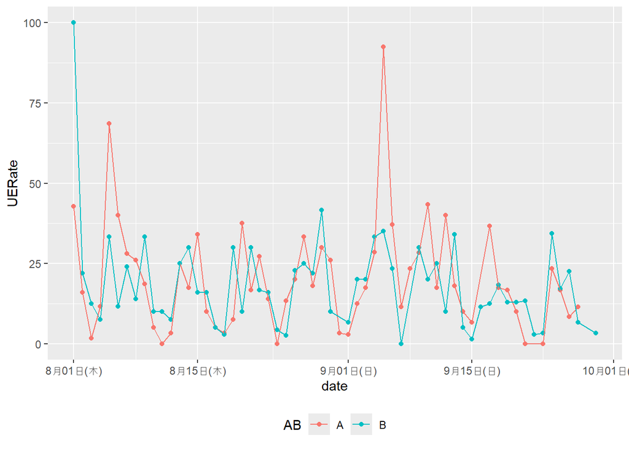

2024-08-01 ~ 2024-09-29における AとBのUERateの平均値: 20.24, 18.37

ScrollRate=scrollした閲覧数/表示比率=1日表示させたときのscroll閲覧数

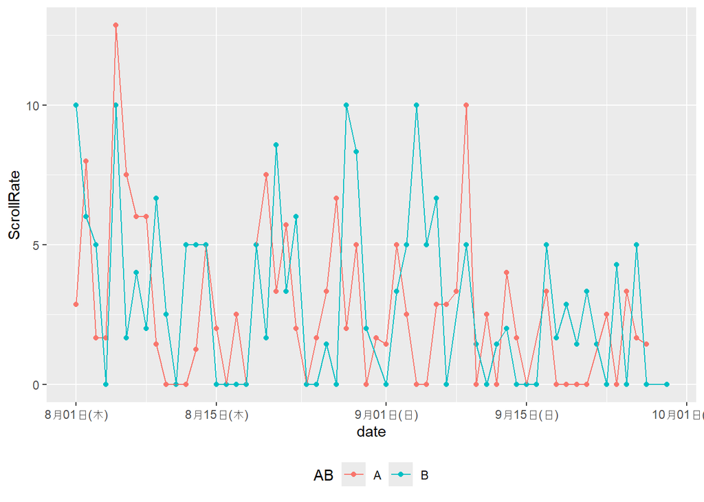

2024-08-01 ~ 2024-09-29における AとBのScrollRateの平均値: 2.7, 3.05

- スクロールは、平均でも標準偏差でも、A/Bの差があまりない

# 4 推計

曜日効果

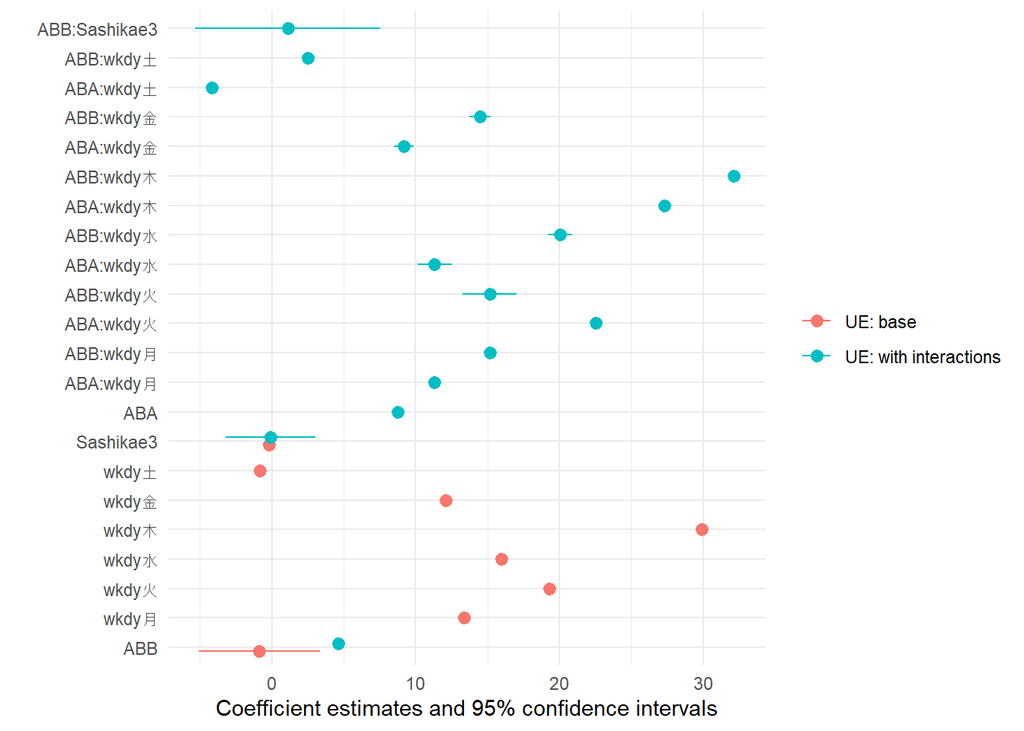

曜日効果のB-A差

|  | UE: base | UE: with interactions | SR: base | SR: with interactions |
| --- | --- | --- | --- | --- |
| ABB | -0.854 | -4.099 | 0.507 | -0.978 |
|  | (0.693) | (<0.001) | (0.415) | (<0.001) |
| Sashikae3 | -0.193 | -0.072 | 0.235 | -0.001 |
|  | (0.248) | (0.964) | (0.509) | (0.999) |
| ABB × wkdy月 |  | 3.871 |  | -0.829 |
|  |  | (<0.001) |  | (<0.001) |
| ABB × wkdy火 |  | -7.409 |  | 0.574 |
|  |  | (<0.001) |  | (0.057) |
| ABB × wkdy水 |  | 8.733 |  | 2.977 |
|  |  | (<0.001) |  | (<0.001) |
| ABB × wkdy木 |  | 4.819 |  | 3.110 |
|  |  | (<0.001) |  | (<0.001) |
| ABB × wkdy金 |  | 5.297 |  | 2.086 |
|  |  | (<0.001) |  | (<0.001) |
| ABB × wkdy土 |  | 6.696 |  | 1.231 |
|  |  | (<0.001) |  | (<0.001) |
| ABB × Sashikae3 |  | 1.129 |  | 0.538 |
|  |  | (0.733) |  | (0.517) |
| Num.Obs. | 117 | 117 | 117 | 117 |
| R2 | 0.331 | 0.351 | 0.184 | 0.242 |
| R2 Adj. | 0.282 | 0.255 | 0.123 | 0.130 |
| R2 Within | 0.001 | 0.031 | 0.011 | 0.082 |
| R2 Within Adj. | -0.018 | -0.055 | -0.007 | 0.000 |
| AIC | 973.3 | 983.7 | 581.6 | 586.9 |
| BIC | 998.2 | 1027.9 | 606.4 | 631.1 |
| RMSE | 14.35 | 14.13 | 2.69 | 2.59 |
| Std.Errors | by: wkdy | by: wkdy | by: wkdy | by: wkdy |
| FE: wkdy | X | X | X | X |

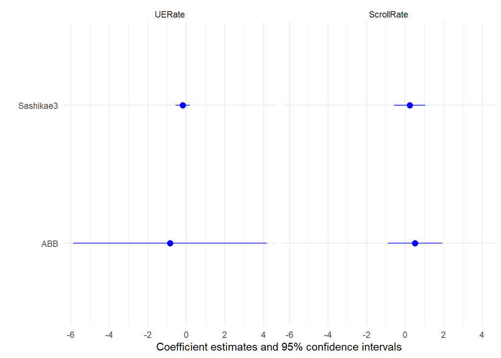

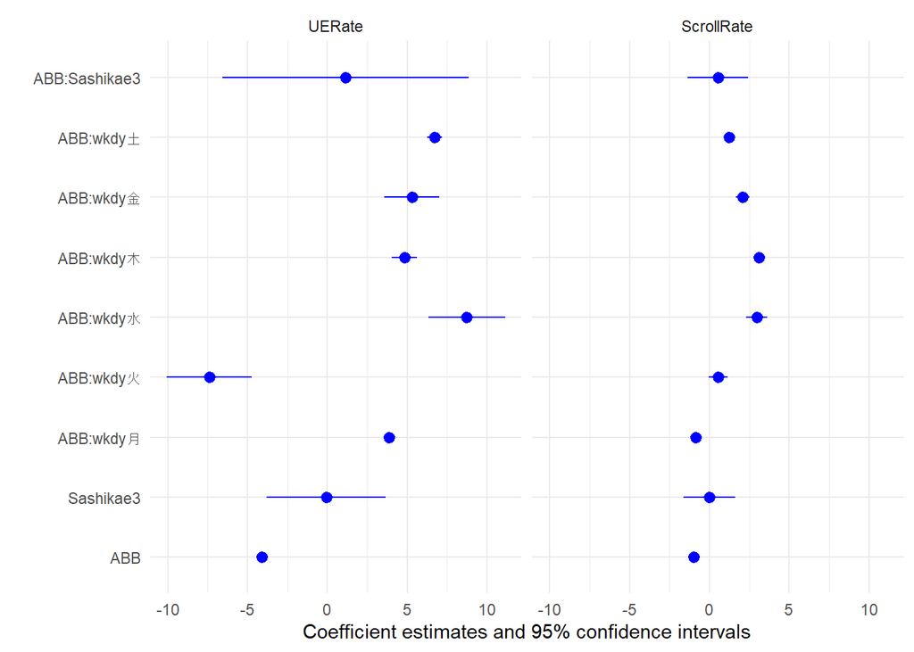

user engagement rates:

- 曜日効果(曜日によるアクセス多寡)はあるが、解釈できない
- A/B: どちらが優れているとは言えない
- トップ記事差し替え効果: 認められない

scroll rates:

- 曜日効果(曜日によるアクセス多寡)はあるが、解釈できない
  - UEもscrollも似たような曜日効果
- A/B: どちらが優れているとは言えない
- トップ記事差し替え効果: 認められない

# 5 結論

Summary of A/B tests

| variables | mean | variability |
| --- | --- | --- |
| UserEngagementRate |  | +A |
| ScrollRate |  |  |

- A/B: いずれの結果指標においても、どちらが優れているとは言えない

# 6 Past news

### What’s new 2024-09-05

- user engagement rateの振幅幅: $A>B$ の傾向が続いている
  - 平均値はほぼ同じ
- scrollではA/Bの差はあまりない
- 前回指摘した「週後半に閲覧数が落ちる傾向」がより鮮明になってきた
  - なんとかすべきかも

### What’s new 2024-08-29

- user engagement rateの振幅幅: $A>B$ の傾向あり、AはUERate=0が2日あり
  - 異常値(UERate$\geqslant 50$)抜きだと、平均は両者ほぼ同じ、標準偏差はAが3割ほど高い